# BST 219: Core Principles of Data Science

R Basics

# 1 Introduction

Welcome! This document is a **friendly, hands-on introduction to the R programming language**, written for graduate students in public health who have little or no prior coding experience. You do not need to be a programmer to succeed here — you just need curiosity and a willingness to try things.

**Why does this matter for public health?** Nearly every question in modern public health — *Which states have the highest mortality rates? Is life expectancy improving over time? Are admissions rates fair across groups?* — is answered with **data**. R is one of the most widely used free tools in the world for working with health data. Learning it lets you:

- clean and organize messy real-world data,
- calculate rates, summaries, and statistics,
- create figures for reports and publications, and
- do all of the above in a way that is **reproducible** — meaning anyone (including future-you) can re-run your analysis and get the same answer.

**What you will learn in this document.** We start from the smallest building blocks and work upward:

1. **Data Types** — the different kinds of information R can store (numbers, text, logical true/false values, and tables).
2. **Vectors** — how R stores a *sequence* of values, which is the heart of almost everything in R.
3. **Sorting** — putting data in order and finding the largest or smallest values.
4. **Indexing** — pulling out exactly the pieces of data you want (a superpower for filtering).
5. **Basic Plots** — turning numbers into pictures.
6. **Programming Basics** — writing simple logic, functions, and loops to automate work.

Throughout, we use small, real public-health-flavored datasets that come built into the `dslabs` package, so you can run every example yourself.

How to use this document Read the explanation, then look at the code chunk directly below it, then look at the output. Every line of code has a `#` comment explaining what it does. Try changing a value and re-running the chunk — breaking things and fixing them is how people learn R.

Before you begin This document uses only **one** add-on package, `dslabs`. If you have never installed it, run this **once** in your R console (not in this document): `install.packages("dslabs")`. After that, the line `library(dslabs)` loads it whenever you need it.

# 2 Data Types

Everything in R is a piece of information with a **type**. Knowing the type matters because R treats numbers, words, and true/false values very differently. The function `class()` tells you the type of any object.

In the chunk below we create several objects using the **assignment arrow** `<-` (read it as *“gets”*: `x <- 2` means *“x gets the value 2”*), and then ask R for the class of each.

```r
x <- 2            # A whole number... but R stores it as "numeric" (a decimal) by default
class(x)          # -> "numeric"
```

```
#> [1] "numeric"
```

```r
y <- 3.14         # A number with a decimal point
class(y)          # -> "numeric"
```

```
#> [1] "numeric"
```

```r
z <- "Boston"     # Text (called a "character string") — note the quotation marks
class(z)          # -> "character"
```

```
#> [1] "character"
```

```r
a <- TRUE         # A logical value: either TRUE or FALSE (no quotes)
class(a)          # -> "logical"
```

```
#> [1] "logical"
```

```r
data(gapminder)   # Load the built-in "gapminder" dataset from dslabs
d <- gapminder    # Copy it into a shorter name, d, so it's easier to type
class(d)          # -> "data.frame": a table with rows and columns
```

```
#> [1] "data.frame"
```

```r
# A "list" can hold many different types of information together in one object.
record <- list(name = "John Doe",
               student_id = 1234,
               grades = c(95, 82, 91, 97, 93),
               final_grade = "A")
class(record)     # -> "list"
```

```
#> [1] "list"
```

```r
# test
```

Key idea The four everyday “atomic” types are **numeric** (numbers), **character** (text in quotes), **logical** (`TRUE`/`FALSE`), and **integer**. A **data frame** is a table (rows = observations, columns = variables) — this is how nearly all health datasets are stored. A **list** is a flexible container that can hold a mix of anything.

## 2.1 Looking inside a dataset

Before analyzing data, you should always *look* at it. Two workhorse functions help: `str()` shows the **str**ucture (variable names, types, and a few example values), and `head()` shows the first six rows.

```r
data(gapminder)   # Make sure the gapminder data is loaded
str(gapminder)    # Show the structure: each variable, its type, and sample values
```

```
#> 'data.frame':    10545 obs. of  9 variables:
#>  $ country         : Factor w/ 185 levels "Albania","Algeria",..: 1 2 3 4 5 6 7 8 9 10 ...
#>  $ year            : int  1960 1960 1960 1960 1960 1960 1960 1960 1960 1960 ...
#>  $ infant_mortality: num  115.4 148.2 208 NA 59.9 ...
#>  $ life_expectancy : num  62.9 47.5 36 63 65.4 ...
#>  $ fertility       : num  6.19 7.65 7.32 4.43 3.11 4.55 4.82 3.45 2.7 5.57 ...
#>  $ population      : num  1636054 11124892 5270844 54681 20619075 ...
#>  $ gdp             : num  NA 1.38e+10 NA NA 1.08e+11 ...
#>  $ continent       : Factor w/ 5 levels "Africa","Americas",..: 4 1 1 2 2 3 2 5 4 3 ...
#>  $ region          : Factor w/ 22 levels "Australia and New Zealand",..: 19 11 10 2 15 21 2 1 22 21 ...
```

```r
head(gapminder)   # Show just the first 6 rows so we can eyeball the table
```

|  | country | year | infant_mortality | life_expectancy | fertility | population | gdp | continent | region |
| --- | --- | --- | --- | --- | --- | --- | --- | --- | --- |
| 1 | Albania | 1960 | 115.40 | 62.87 | 6.19 | 1636054 | NA | Europe | Southern Europe |
| 2 | Algeria | 1960 | 148.20 | 47.50 | 7.65 | 11124892 | 13828152297 | Africa | Northern Africa |
| 3 | Angola | 1960 | 208.00 | 35.98 | 7.32 | 5270844 | NA | Africa | Middle Africa |
| 4 | Antigua and Barbuda | 1960 | NA | 62.97 | 4.43 | 54681 | NA | Americas | Caribbean |
| 5 | Argentina | 1960 | 59.87 | 65.39 | 3.11 | 20619075 | 108322326649 | Americas | South America |
| 6 | Armenia | 1960 | NA | 66.86 | 4.55 | 1867396 | NA | Asia | Western Asia |

## 2.2 Columns, and the `$` operator

Each column in a data frame is a variable. The dollar sign `$` is how you grab a single column by name, using the pattern `dataset$column`.

Here we load a small dataset of university `admissions` and pull out its `major` column.

```r
data(admissions)      # Load the built-in admissions dataset
names(admissions)     # List the column (variable) names in the table
```

```
#> [1] "major"      "gender"     "admitted"   "applicants"
```

```r
admissions$major      # Extract the "major" column using dataset$column
```

```
#>  [1] "A" "B" "C" "D" "E" "F" "A" "B" "C" "D" "E" "F"
```

A single column that you have pulled out is itself a **vector** (our next topic). We can measure how long it is and check its type:

```r
majors <- admissions$major   # Save the major column into its own object
length(majors)               # How many values does it contain?
```

```
#> [1] 12
```

```r
class(majors)                # What type are those values?
```

```
#> [1] "character"
```

Columns can also be **factors** — a special type R uses for categories (like region or country). Factors look like text but are stored efficiently as labeled categories.

```r
head(gapminder)              # Peek at the gapminder table again
```

|  | country | year | infant_mortality | life_expectancy | fertility | population | gdp | continent | region |
| --- | --- | --- | --- | --- | --- | --- | --- | --- | --- |
| 1 | Albania | 1960 | 115.40 | 62.87 | 6.19 | 1636054 | NA | Europe | Southern Europe |
| 2 | Algeria | 1960 | 148.20 | 47.50 | 7.65 | 11124892 | 13828152297 | Africa | Northern Africa |
| 3 | Angola | 1960 | 208.00 | 35.98 | 7.32 | 5270844 | NA | Africa | Middle Africa |
| 4 | Antigua and Barbuda | 1960 | NA | 62.97 | 4.43 | 54681 | NA | Americas | Caribbean |
| 5 | Argentina | 1960 | 59.87 | 65.39 | 3.11 | 20619075 | 108322326649 | Americas | South America |
| 6 | Armenia | 1960 | NA | 66.86 | 4.55 | 1867396 | NA | Asia | Western Asia |

```r
class(gapminder$country)     # The "country" column is a factor (a categorical variable)
```

```
#> [1] "factor"
```

# 3 Vectors

A **vector** is simply an ordered sequence of values of the *same type* — think of it as a single column of a spreadsheet. Vectors are the most important object in R: almost every dataset is built from them. We create vectors with the function `c()`, which stands for **c**ombine.

```r
codes <- c(380, 124, 818)          # A numeric vector of three country codes
codes
```

```
#> [1] 380 124 818
```

```r
country <- c("italy", "canada", "egypt")   # A character vector (note the quotes!)
country
```

```
#> [1] "italy"  "canada" "egypt"
```

Common beginner error Text values always need quotes. The chunk below tries to build a vector from *unquoted* words, so R looks for objects named `italy`, `canada`, and `egypt`, can’t find them, and throws an error. (This chunk is set not to run so the document still knits — try running it yourself to see the error message.)

```r
country <- c(italy, canada, egypt)   # ERROR: no quotes, so R can't find these "objects"
```

## 3.1 Naming the elements of a vector

You can attach a **name** to each element, which makes vectors much easier to read. There are three equivalent ways to do it:

```r
# Way 1: assign names inside c() using name = value
codes <- c(italy = 380, canada = 124, egypt = 818)
codes
```

```
#>  italy canada  egypt
#>    380    124    818
```

```r
names(codes)          # Show just the names
```

```
#> [1] "italy"  "canada" "egypt"
```

```r
# Way 2: same thing, but with the names in quotes (also fine)
codes <- c("italy" = 380, "canada" = 124, "egypt" = 818)
codes
```

```
#>  italy canada  egypt
#>    380    124    818
```

```r
# Way 3: build the values first, then add names afterward with names()
codes <- c(380, 124, 818)
country <- c("italy", "canada", "egypt")
names(codes) <- country     # Attach the country names to the code values
codes
```

```
#>  italy canada  egypt
#>    380    124    818
```

## 3.2 Creating sequences

R gives you quick shortcuts for building runs of numbers. `seq()` makes a **seq**uence, and the colon `:` is a shortcut for counting by ones.

```r
seq(1, 10)               # The numbers 1 through 10
```

```
#>  [1]  1  2  3  4  5  6  7  8  9 10
```

```r
seq(1, 10, 2)            # From 1 to 10, counting by 2: 1, 3, 5, 7, 9
```

```
#> [1] 1 3 5 7 9
```

```r
1:10                     # Shortcut for seq(1, 10)
```

```
#>  [1]  1  2  3  4  5  6  7  8  9 10
```

```r
class(1:10)              # -> "integer" (the colon makes whole-number integers)
```

```
#> [1] "integer"
```

```r
class(seq(1, 10, 0.5))   # -> "numeric" (step of 0.5 forces decimals)
```

```
#> [1] "numeric"
```

## 3.3 Subsetting: pulling out specific elements

To grab elements from a vector, put their **position number(s)** or **name(s)** inside square brackets `[ ]`. This is called *subsetting* or *indexing*.

```r
codes                        # The full named vector, for reference
```

```
#>  italy canada  egypt
#>    380    124    818
```

```r
codes[2]                     # The 2nd element (R counts starting at 1, not 0!)
```

```
#> canada
#>    124
```

```r
codes[c(1, 3)]               # Elements 1 and 3 together
```

```
#> italy egypt
#>   380   818
```

```r
codes[1:2]                   # Elements 1 through 2
```

```
#>  italy canada
#>    380    124
```

```r
codes["canada"]              # Grab by name instead of position
```

```
#> canada
#>    124
```

```r
codes[c("egypt", "italy")]   # Multiple elements by name, in any order you like
```

```
#> egypt italy
#>   818   380
```

## 3.4 Coercion: when R changes types on you

A vector can only hold **one** type. If you mix types, R silently converts (or *coerces*) everything to the most flexible common type — usually character (text). This is a very common source of surprises, so it is worth seeing on purpose.

```r
x <- c(1, "canada", 3)   # Mixing a number and text...
x
```

```
#> [1] "1"      "canada" "3"
```

```r
class(x)                 # -> "character": the numbers got turned into text!
```

```
#> [1] "character"
```

```r
x <- 1:5                 # A clean numeric (integer) vector
y <- as.character(x)     # Deliberately convert numbers to text
y
```

```
#> [1] "1" "2" "3" "4" "5"
```

```r
as.numeric(y)            # Convert text back to numbers — this works because it's "1","2",...
```

```
#> [1] 1 2 3 4 5
```

When R can’t sensibly convert a value to a number, it returns `NA` (**N**ot **A**vailable, R’s marker for missing data) and warns you:

```r
x <- c("1", "b", "3")   # "b" is not a number
as.numeric(x)           # -> 1, NA, 3  (the "b" becomes NA because it can't be a number)
```

```
#> [1]  1 NA  3
```

Key idea If a calculation mysteriously fails, check your types with `class()`. Numbers hiding inside quotes (“42” instead of 42) are one of the most common causes of errors for beginners.

# 4 Sorting

Sorting helps us find patterns — the highest and lowest values, rankings, and order. We’ll use the `murders` dataset (U.S. gun murders by state in 2010) to practice.

`sort()` simply arranges the values from smallest to largest.

```r
data(murders)            # Load the U.S. gun murders dataset
sort(murders$total)      # Sort the "total murders" column from lowest to highest
```

```
#>  [1]    2    4    5    5    7    8   11   12   12   16   19   21   22   27   32
#> [16]   36   38   53   63   65   67   84   93   93   97   97   99  111  116  118
#> [31]  120  135  142  207  219  232  246  250  286  293  310  321  351  364  376
#> [46]  413  457  517  669  805 1257
```

## 4.1 `order()` — sorting *one* thing by *another*

`sort()` reorders values but loses track of *which state* each value belonged to. `order()` solves this: instead of the sorted values, it returns the **positions** that *would* sort the vector. You can then use those positions to reorder a *related* column.

```r
x <- c(31, 4, 15, 92, 65)   # A small example vector
sort(x)                     # The values in order: 4, 15, 31, 65, 92
```

```
#> [1]  4 15 31 65 92
```

```r
index <- order(x)           # The POSITIONS that put x in order: 2, 3, 1, 5, 4
x[index]                    # Using those positions reproduces the sorted values
```

```
#> [1]  4 15 31 65 92
```

```r
x                           # (x itself is unchanged)
```

```
#> [1] 31  4 15 92 65
```

```r
order(x)                    # Show the ordering positions again
```

```
#> [1] 2 3 1 5 4
```

```r
data(murders)
ind <- order(murders$total)   # Positions that sort states from fewest to most murders
murders$abb[ind]              # Use them to list state abbreviations in that same order
```

```
#>  [1] "VT" "ND" "NH" "WY" "HI" "SD" "ME" "ID" "MT" "RI" "AK" "IA" "UT" "WV" "NE"
#> [16] "OR" "DE" "MN" "KS" "CO" "NM" "NV" "AR" "WA" "CT" "WI" "DC" "OK" "KY" "MA"
#> [31] "MS" "AL" "IN" "SC" "TN" "AZ" "NJ" "VA" "NC" "MD" "OH" "MO" "LA" "IL" "GA"
#> [46] "MI" "PA" "NY" "FL" "TX" "CA"
```

## 4.2 Finding the maximum (and where it is)

`max()` gives the largest value; `which.max()` gives its **position**, which you can use to look up the matching state.

```r
max(murders$total)              # The single largest number of murders
```

```
#> [1] 1257
```

```r
i_max <- which.max(murders$total)   # The POSITION of that largest value
i_max
```

```
#> [1] 5
```

```r
murders$state[i_max]            # Use that position to find WHICH state it was
```

```
#> [1] "California"
```

## 4.3 Ranking

`rank()` reports each value’s rank (1 = smallest), keeping the original order of the vector.

```r
x <- c(31, 4, 15, 92, 65)   # Same example vector
rank(x)                     # -> 3 1 2 5 4  (e.g., 31 is the 3rd smallest)
```

```
#> [1] 3 1 2 5 4
```

# 5 Indexing

**Indexing** — using `[ ]` together with logic — is how you *filter* data to answer real questions. This section is the analytic heart of the whole document.

First, a warm-up combining ideas from before: compute a murder **rate** (murders per 100,000 people, so states of different sizes can be compared fairly), then order the states by that rate.

```r
i_max <- which.max(murders$total)   # Position of the most murders (from before)
murders$state[i_max]                # Which state that is
```

```
#> [1] "California"
```

```r
head(murders)                       # Reminder of what the table looks like
```

|  | state | abb | region | population | total |
| --- | --- | --- | --- | --- | --- |
| 1 | Alabama | AL | South | 4779736 | 135 |
| 2 | Alaska | AK | West | 710231 | 19 |
| 3 | Arizona | AZ | West | 6392017 | 232 |
| 4 | Arkansas | AR | South | 2915918 | 93 |
| 5 | California | CA | West | 37253956 | 1257 |
| 6 | Colorado | CO | West | 5029196 | 65 |

```r
# Murder RATE = murders divided by population, scaled to a per-100,000 basis
murder_rate <- murders$total / murders$population * 100000

murders$state[order(murder_rate)]   # States listed from lowest to highest murder RATE
```

```
#>  [1] "Vermont"              "New Hampshire"        "Hawaii"
#>  [4] "North Dakota"         "Iowa"                 "Idaho"
#>  [7] "Utah"                 "Maine"                "Wyoming"
#> [10] "Oregon"               "South Dakota"         "Minnesota"
#> [13] "Montana"              "Colorado"             "Washington"
#> [16] "West Virginia"        "Rhode Island"         "Wisconsin"
#> [19] "Nebraska"             "Massachusetts"        "Indiana"
#> [22] "Kansas"               "New York"             "Kentucky"
#> [25] "Alaska"               "Ohio"                 "Connecticut"
#> [28] "New Jersey"           "Alabama"              "Illinois"
#> [31] "Oklahoma"             "North Carolina"       "Nevada"
#> [34] "Virginia"             "Arkansas"             "Texas"
#> [37] "New Mexico"           "California"           "Florida"
#> [40] "Tennessee"            "Pennsylvania"         "Arizona"
#> [43] "Georgia"              "Mississippi"          "Michigan"
#> [46] "Delaware"             "South Carolina"       "Maryland"
#> [49] "Missouri"             "Louisiana"            "District of Columbia"
```

## 5.1 Logical indexing (filtering)

Comparisons like `<`, `>`, and `==` produce **logical vectors** of `TRUE`/`FALSE`. Placing a logical vector inside `[ ]` keeps only the elements where the condition is `TRUE`. This is filtering.

```r
murder_rate <- murders$total / murders$population * 100000
ind <- murder_rate < 0.71   # TRUE for each state with a rate below 0.71, FALSE otherwise
ind                         # A vector of TRUE/FALSE values, one per state
```

```
#>  [1] FALSE FALSE FALSE FALSE FALSE FALSE FALSE FALSE FALSE FALSE FALSE  TRUE
#> [13] FALSE FALSE FALSE  TRUE FALSE FALSE FALSE FALSE FALSE FALSE FALSE FALSE
#> [25] FALSE FALSE FALSE FALSE FALSE  TRUE FALSE FALSE FALSE FALSE  TRUE FALSE
#> [37] FALSE FALSE FALSE FALSE FALSE FALSE FALSE FALSE FALSE  TRUE FALSE FALSE
#> [49] FALSE FALSE FALSE
```

```r
sum(ind)                    # TRUE counts as 1, so sum() tells us HOW MANY states qualify
```

```
#> [1] 5
```

```r
murders$state[ind]          # Keep only the states where ind is TRUE
```

```
#> [1] "Hawaii"        "Iowa"          "New Hampshire" "North Dakota"
#> [5] "Vermont"
```

Handy trick Because `TRUE` equals 1 and `FALSE` equals 0, `sum()` on a logical vector *counts* how many conditions are true, and `mean()` gives the *proportion* that are true.

## 5.2 Combining conditions: `&`, `|`, and `!`

You can join conditions with **AND** (`&`, both must be true), **OR** (`|`, at least one true), and **NOT** (`!`, flips true/false).

```r
TRUE & TRUE        # AND: TRUE only if both sides are TRUE
```

```
#> [1] TRUE
```

```r
TRUE & FALSE       # AND: FALSE, because one side is FALSE
```

```
#> [1] FALSE
```

```r
FALSE & FALSE      # AND: FALSE
```

```
#> [1] FALSE
```

```r
west <- murders$region == "West"   # TRUE for states in the West region
safe <- murder_rate <= 1           # TRUE for states with a low murder rate

ind <- safe & west                 # Safe AND in the West
murders$state[ind]
```

```
#> [1] "Hawaii"  "Idaho"   "Oregon"  "Utah"    "Wyoming"
```

```r
ind <- safe | west                 # Safe OR in the West (either condition)
murders$state[ind]
```

```
#>  [1] "Alaska"        "Arizona"       "California"    "Colorado"
#>  [5] "Hawaii"        "Idaho"         "Iowa"          "Maine"
#>  [9] "Minnesota"     "Montana"       "Nevada"        "New Hampshire"
#> [13] "New Mexico"    "North Dakota"  "Oregon"        "South Dakota"
#> [17] "Utah"          "Vermont"       "Washington"    "Wyoming"
```

```r
ind <- safe & !west                # Safe AND NOT in the West
murders$state[ind]
```

```
#> [1] "Iowa"          "Maine"         "Minnesota"     "New Hampshire"
#> [5] "North Dakota"  "South Dakota"  "Vermont"
```

## 5.3 Finding positions: `which()`, `match()`, and `%in%`

`which()` returns the positions where a condition is `TRUE` — useful to locate one specific record.

```r
ind <- which(murders$state == "California")   # Position of the California row
ind   # this is the index that matches the California entry
```

```
#> [1] 5
```

```r
murder_rate[ind]   # Look up California's murder rate using that position
```

```
#> [1] 3.374138
```

`match()` finds the positions of several items at once, in the order you asked for. If an item isn’t found, it returns `NA`.

```r
ind <- match(c("New York", "Florida", "Texas"), murders$state)   # Positions of these 3 states
ind
```

```
#> [1] 33 10 44
```

```r
match(c("Boston", "Dakota", "Washington"), murders$state)        # "Boston"/"Dakota" -> NA (not states)
```

```
#> [1] NA NA 48
```

```r
murder_rate[ind]                                                 # Rates for NY, FL, TX
```

```
#> [1] 2.667960 3.398069 3.201360
```

`%in%` answers a simple yes/no question for each item: *is it in this set?*

```r
# For each name, is it found in the list of state names? (TRUE/FALSE)
c("Boston", "Dakota", "Washington") %in% murders$state
```

```
#> [1] FALSE FALSE  TRUE
```

# 6 Basic Plots

A picture often reveals what a table of numbers hides. R has built-in plotting functions (no extra packages needed) for the four most common chart types.

## 6.1 Scatterplot

A **scatterplot** shows the relationship between two numeric variables — here, whether states with larger populations tend to have more murders.

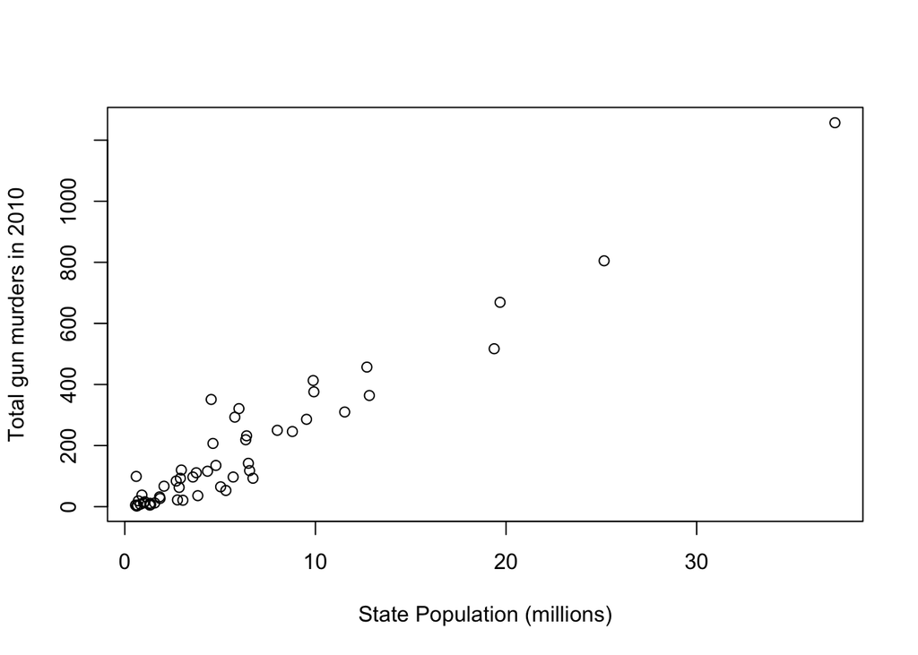

```r
population_in_millions <- murders$population / 10^6   # Convert population to millions (easier to read)
total_gun_murders <- murders$total                    # The number of murders per state

plot(x = population_in_millions, y = total_gun_murders,   # x vs y
     xlab = "State Population (millions)",                # Label the x-axis
     ylab = "Total gun murders in 2010")                  # Label the y-axis
```

## 6.2 Histogram

A **histogram** shows the distribution of a *single* numeric variable by grouping values into bars.

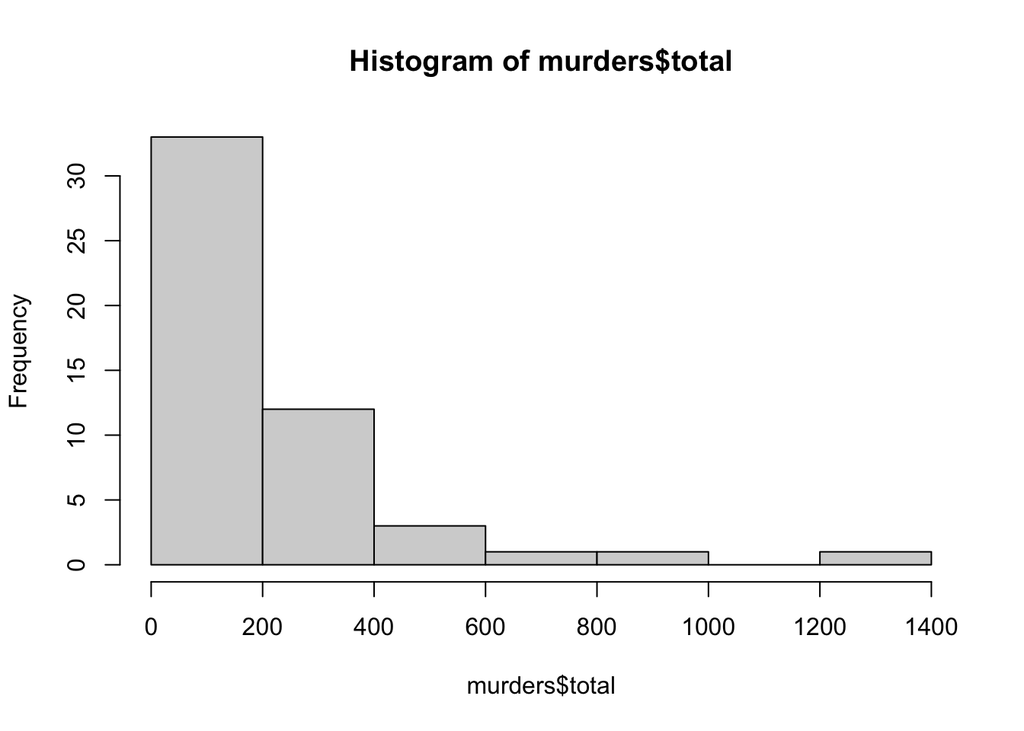

```r
hist(murders$total)                          # Quick default histogram of total murders
```

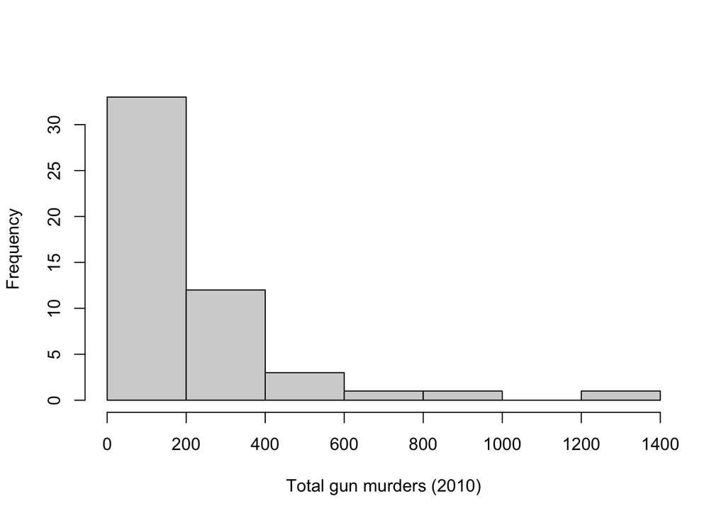

```r
hist(murders$total, xlab = "Total gun murders (2010)",   # Add a clearer x-axis label
     main = "")                              # main = "" removes the default title
```

## 6.3 Boxplot

A **boxplot** compares the distribution of a numeric variable *across categories* — here, murders by U.S. region. The `~` (tilde) is read as *“by”*: `total ~ region` means “total murders **by** region.”

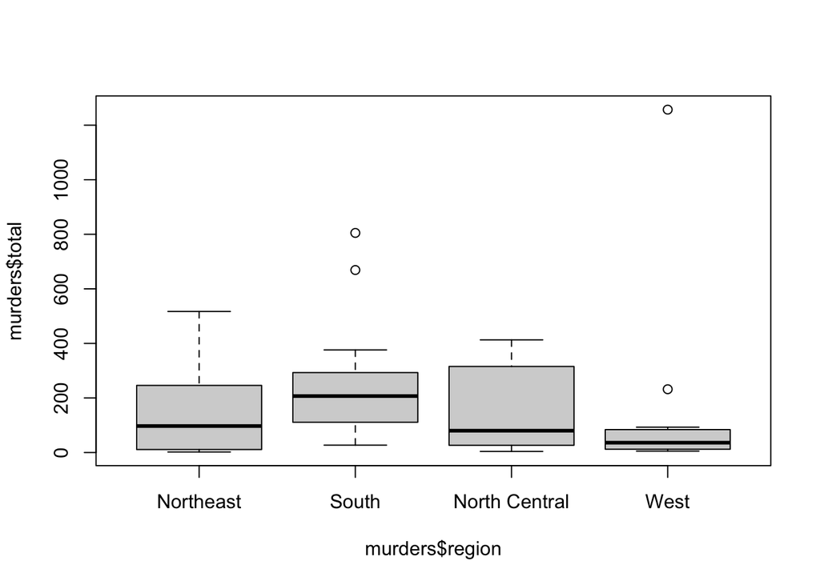

```r
boxplot(murders$total ~ murders$region)      # Distribution of murders, split by region
```

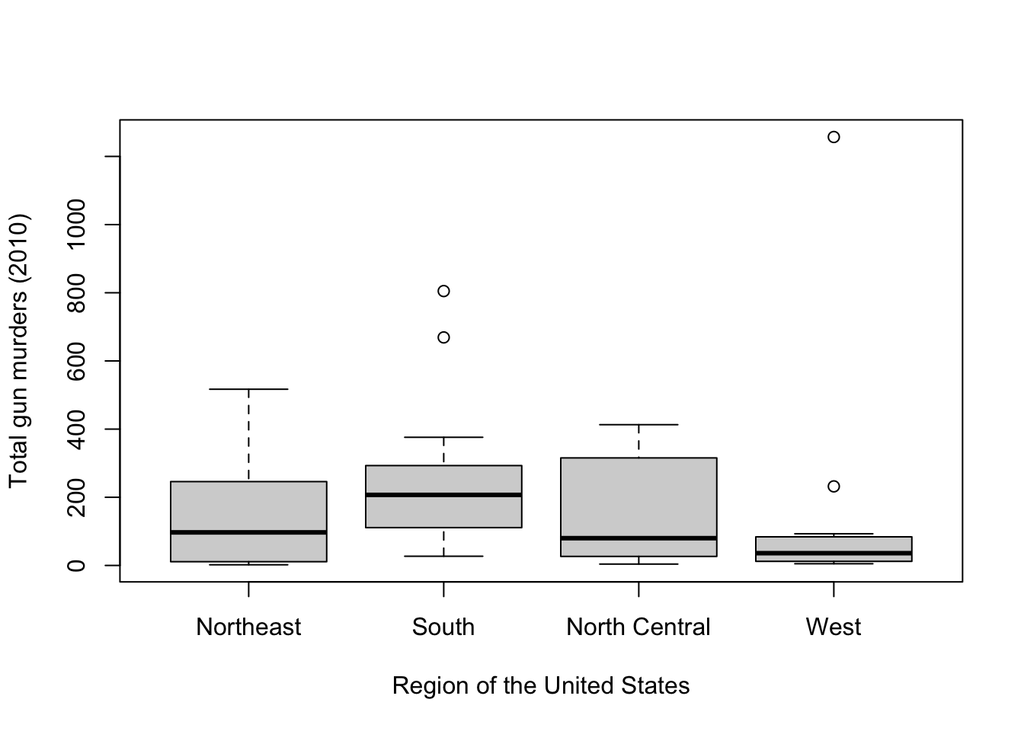

```r
boxplot(murders$total ~ murders$region,      # Same plot, with readable axis labels
        xlab = "Region of the United States",
        ylab = "Total gun murders (2010)")
```

## 6.4 Bar plot

A **bar plot** shows a value for each category using bar height. Here we first build a tiny summary table by hand, then plot it.

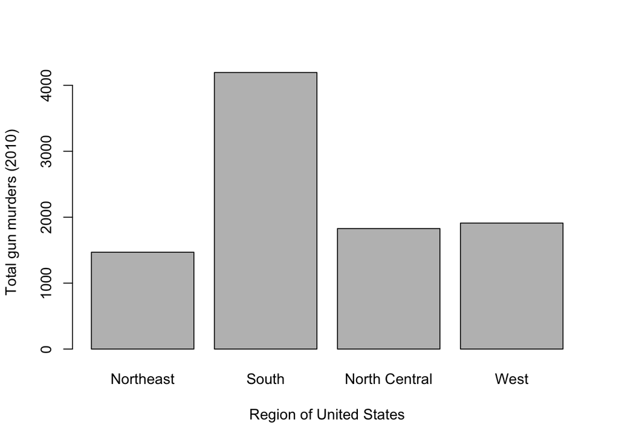

```r
# Build a small data frame of region totals to plot
data <- data.frame(
  name  = c("Northeast", "South", "North Central", "West"),
  value = c(1469, 4195, 1828, 1911))

barplot(height = data$value, names = data$name,   # Bar heights and their labels
        xlab = "Region of United States",
        ylab = "Total gun murders (2010)")
```

# 7 Programming Basics

So far we’ve asked R to do one thing at a time. Real analyses often need **logic** (“if this, then that”), **functions** (reusable recipes), and **loops** (repeat a task). These three tools let you automate work and avoid copy-paste mistakes.

## 7.1 Making decisions: `if` / `else`

An `if...else` statement runs one block of code when a condition is `TRUE` and another when it is `FALSE`.

```r
a <- 0

# Because a IS 0, the condition (a != 0) is FALSE, so the else branch runs.
if(a != 0){
  print(1/a)                          # Runs only if a is NOT zero
} else{
  print("No reciprocal for 0.")       # Runs when a is zero (dividing by 0 is undefined)
}
```

```
#> [1] "No reciprocal for 0."
```

```r
a <- 2

# Now a is 2, so (a != 0) is TRUE and the first branch runs.
if(a != 0){
  print(1/a)                          # Prints 0.5
} else{
  print("No reciprocal for 0.")
}
```

```
#> [1] 0.5
```

## 7.2 Vectorized decisions: `ifelse()`

`if` handles a single value. `ifelse()` handles a **whole vector** at once, checking the condition element by element — extremely useful for whole columns of data.

```r
a <- 0
ifelse(a > 0, 1/a, NA)   # If a > 0 return 1/a, otherwise return NA. Here -> NA
```

```
#> [1] NA
```

```r
a <- c(0, 1, 2, -4, 5)               # A vector of values
result <- ifelse(a > 0, 1/a, NA)     # Element by element: reciprocal if positive, else NA
result                               # -> NA, 1.0, 0.5, NA, 0.2
```

```
#> [1]  NA 1.0 0.5  NA 0.2
```

Here’s `ifelse()` used to write a plain-language message about the data:

```r
data(murders)
murder_rate <- murders$total / murders$population * 100000
ind <- which.min(murder_rate)        # Position of the LOWEST murder rate

# If the lowest rate is below 0.5, report that state; otherwise print a message.
ifelse(murder_rate[ind] < 0.5, murders$state[ind],
       print("Minimum murder rate is not that low."))
```

```
#> [1] "Vermont"
```

```r
# Same test with a stricter cutoff of 0.25 (the lowest rate is above this).
ifelse(murder_rate[ind] < 0.25, murders$state[ind],
       print("Minimum murder rate is not that low."))
```

```
#> [1] "Minimum murder rate is not that low."
```

```
#> [1] "Minimum murder rate is not that low."
```

## 7.3 Writing your own function

A **function** is a reusable recipe: you give it inputs, it runs some steps, and it returns an output. Defining one means you can reuse it forever without rewriting the code.

```r
# This function takes a state abbreviation and reports that state's murder rate.
murder_rate_by_state <- function(state_abbr) {
  # Keep only the row(s) whose abbreviation matches the input
  state_data <- murders[murders$abb == state_abbr, ]

  # Safety check: if no row matched, stop and warn the user
  if (nrow(state_data) == 0) {
    stop("Invalid state abbreviation.")
  }

  # Calculate the murder rate per 100,000 people
  rate <- (state_data$total / state_data$population) * 100000

  # Build and return a friendly sentence with the result
  paste("The murder rate in", state_data$state, "is",
        round(rate, 2), "per 100,000 people.")
}
```

Now we can **call** (use) the function with different inputs:

```r
murder_rate_by_state("NY")        # New York
```

```
#> [1] "The murder rate in New York is 2.67 per 100,000 people."
```

```r
murder_rate_by_state("CA")        # California
```

```
#> [1] "The murder rate in California is 3.37 per 100,000 people."
```

```r
# "ZZ" isn't a real state, so the function's safety check triggers stop().
# We wrap it in try() so the error is caught and the document still knits.
try(murder_rate_by_state("ZZ"))
```

```
#> Error in murder_rate_by_state("ZZ") : Invalid state abbreviation.
```

The general shape of every function looks like this (shown for reference; not run):

```r
# Anatomy of a function
name <- function(x){   # "name" is what you'll call it; x is the input
  code to run          # the steps the function performs
  output               # the last value is returned as the result
}
```

A tiny function that averages a set of numbers:

```r
avg <- function(x){    # x is the input vector of numbers
  s <- sum(x)          # Add up all the values
  n <- length(x)       # Count how many values there are
  s / n                # The last line is returned: the mean
}

x <- 1:100             # The numbers 1 through 100
avg(x)                 # -> 50.5 (their average)
```

```
#> [1] 50.5
```

## 7.4 Repeating with `for` loops

A **loop** repeats a task many times. A `for` loop runs its body once for each value in a sequence — here, `i` takes the values 1, 2, 3, 4, 5 in turn.

```r
for(i in 1:5){   # Repeat for i = 1, then 2, ... up to 5
  print(i)       # Print the current value of i each time
}
```

```
#> [1] 1
#> [1] 2
#> [1] 3
#> [1] 4
#> [1] 5
```

A more realistic loop: step through each Northeast state and print its murder rate.

```r
# First, filter the data down to just the Northeast region
northeast_data <- murders[murders$region == "Northeast", ]

# Loop over each row (each state) in that filtered table
for (i in 1:nrow(northeast_data)) {
  state_name <- northeast_data$state[i]       # The i-th state's name
  # The i-th state's murder rate per 100,000
  rate <- (northeast_data$total[i] / northeast_data$population[i]) * 100000
  # cat() prints a custom message; "\n" starts a new line
  cat(state_name, "has a murder rate of", round(rate, 2), "per 100,000 people.\n")
}
```

```
#> Connecticut has a murder rate of 2.71 per 100,000 people.
#> Maine has a murder rate of 0.83 per 100,000 people.
#> Massachusetts has a murder rate of 1.8 per 100,000 people.
#> New Hampshire has a murder rate of 0.38 per 100,000 people.
#> New Jersey has a murder rate of 2.8 per 100,000 people.
#> New York has a murder rate of 2.67 per 100,000 people.
#> Pennsylvania has a murder rate of 3.6 per 100,000 people.
#> Rhode Island has a murder rate of 1.52 per 100,000 people.
#> Vermont has a murder rate of 0.32 per 100,000 people.
```

## 7.5 Putting it together

Finally, a small function combined with column extraction — a pattern you’ll use constantly in real analyses.

```r
# A reusable function that turns raw counts into a rate per 100,000
compute_murder_rate <- function(total, population) {
  rate <- (total / population) * 100000
  return(rate)     # return() makes the output explicit (optional but clear)
}

# Pull New York's total murders and population out of the table
ny_total <- murders$total[murders$state == "New York"]
ny_pop   <- murders$population[murders$state == "New York"]

# Feed those values into our function to get New York's rate
compute_murder_rate(ny_total, ny_pop)
```

```
#> [1] 2.66796
```

# 8 Self-Assessment Questions

Try each question **before** revealing the answer. These build from foundational to challenging. Everything you need is covered above and uses only `dslabs` and base R. Click **“Show answer”** to check your work.

## 8.1 Beginner

**Q1.** Create an object called `age` that stores the number `29`, then check its class.

**Show answer**

```r
age <- 29        # Store 29 in an object called age
class(age)       # -> "numeric"
```

**Q2.** Build a character vector called `cities` containing “Boston”, “New York”, and “Chicago”. How long is it?

**Show answer**

```r
cities <- c("Boston", "New York", "Chicago")   # Remember the quotes!
length(cities)                                 # -> 3
```

**Q3.** Using the `murders` dataset, display the first six rows and list the column names.

**Show answer**

```r
data(murders)
head(murders)      # First 6 rows
names(murders)     # Column names: state, abb, region, population, total
```

**Q4.** What will `class(c(1, 2, "three"))` return, and *why*?

**Show answer**

It returns **“character”**. A vector can hold only one type, so R *coerces* the numbers `1` and `2` into text to match `"three"`. This is why mixing types accidentally can turn your numbers into strings.

## 8.2 Intermediate

**Q5.** Add the murder rate (per 100,000) as reasoning: which single state has the *highest* total number of murders? (Hint: `which.max()`.)

**Show answer**

```r
data(murders)
i <- which.max(murders$total)   # Position of the largest total
murders$state[i]                # The state at that position (California)
```

**Q6.** Compute the murder rate per 100,000 for every state, then list only the states with a rate **below 1**.

**Show answer**

```r
murder_rate <- murders$total / murders$population * 100000   # Rate per 100k
ind <- murder_rate < 1        # TRUE/FALSE for each state
murders$state[ind]            # Keep states where the rate is below 1
```

**Q7.** Using logical operators, find the states that are in the `"West"` region **and** have a murder rate at or below 1.

**Show answer**

```r
murder_rate <- murders$total / murders$population * 100000
west <- murders$region == "West"   # In the West?
safe <- murder_rate <= 1           # Low rate?
murders$state[west & safe]         # Both conditions TRUE
```

**Q8.** Use `match()` to find the positions of “Texas” and “Ohio” in `murders$state`, then report their populations.

**Show answer**

```r
ind <- match(c("Texas", "Ohio"), murders$state)   # Positions of the two states
murders$population[ind]                            # Their populations
```

## 8.3 Advanced

**Q9.** Write a function `rate_of()` that takes a state name (e.g., `"Florida"`) and returns its murder rate per 100,000, rounded to two decimals.

**Show answer**

```r
rate_of <- function(state_name){
  row  <- murders[murders$state == state_name, ]        # Filter to that state
  rate <- (row$total / row$population) * 100000          # Compute the rate
  round(rate, 2)                                         # Round and return it
}

rate_of("Florida")   # Try it out
```

**Q10.** Using a `for` loop, print each **Northeast** state together with whether its murder rate is above or below the Northeast average. (Hint: compute the average first, then loop and use `ifelse()`.)

**Show answer**

```r
ne <- murders[murders$region == "Northeast", ]          # Northeast states only
ne_rate <- ne$total / ne$population * 100000            # Rate for each
avg_rate <- mean(ne_rate)                               # Northeast average

for (i in 1:nrow(ne)) {
  label <- ifelse(ne_rate[i] > avg_rate, "ABOVE", "below")  # Compare to average
  cat(ne$state[i], "is", label, "the Northeast average.\n")
}
```

**Q11.** From the `gapminder` dataset, find the average `life_expectancy` for the year 2000. (Hint: filter rows where `year == 2000`, then use `mean()` and handle missing values with `na.rm = TRUE`.)

**Show answer**

```r
data(gapminder)
yr2000 <- gapminder[gapminder$year == 2000, ]       # Keep only year 2000 rows
mean(yr2000$life_expectancy, na.rm = TRUE)          # Average, ignoring any NAs
```

`na.rm = TRUE` tells `mean()` to *remove* missing values before averaging; without it, any `NA` in the data would make the whole result `NA`.

# 9 Frequently Asked Questions (FAQ)

**What is a “chunk,” and how do I run one?** A chunk is the shaded gray box of R code you see throughout this document (each one opens with a line marked `{r}` and closes with a matching fence line). In RStudio, click the small green ▶ arrow in the chunk’s top-right corner to run it, or place your cursor inside and press **Ctrl+Enter** (**Cmd+Enter** on a Mac) to run one line at a time.

**What’s the difference between `<-` and `=`?** Both can assign a value to an object, and `x <- 2` and `x = 2` behave the same here. By strong convention, R users write `<-` for assignment and reserve `=` for setting arguments *inside* a function, like `plot(x = ..., y = ...)`. Following this habit makes your code easier for others (and future-you) to read.

**Why do I keep getting `object 'xyz' not found`?** R is telling you it has never heard of `xyz`. Usually this means (1) you forgot the quotes around text (`Boston` instead of `"Boston"`), (2) you have a typo, or (3) you didn’t run the earlier chunk that created the object. R is **case-sensitive**, so `Murders` and `murders` are different names.

**Do I have to load `library(dslabs)` every time?** You need to run `library(dslabs)` once per R session (each time you open RStudio fresh). You only `install.packages("dslabs")` **once ever** on a given computer. In this document the package is loaded in the hidden setup chunk at the top, so all the examples just work.

**What does the `$` do?** The `$` pulls one column out of a data frame by name: `murders$total` means “the `total` column from the `murders` table.” The result is a vector you can then sort, filter, or plot.

**Why did my numbers turn into text (or turn into `NA`)?** A vector can hold only one type. If you combine numbers with text, R coerces everything to character — so `c(1, "a")` becomes `"1" "a"`. Going the other way, `as.numeric("a")` can’t make a number out of a letter, so it returns `NA` (missing) with a warning. When math suddenly fails, check your types with `class()`.

**What is `NA`, and how is it different from `0` or `"NA"`?** `NA` means **missing / unknown**. It is not zero, and it is not the two-letter text `"NA"`. Most calculations involving `NA` return `NA` on purpose, to stop you from silently ignoring missing data. Many functions accept `na.rm = TRUE` to skip missing values (e.g., `mean(x, na.rm = TRUE)`).

**Why does R start counting at 1?** Unlike some programming languages that start at 0, R indexes from **1**, so `x[1]` is the first element. This tends to feel natural to people coming from statistics and spreadsheets.

**How do I get help on a function?** Type a question mark followed by the function name in the console, e.g. `?mean` or `?sort`, to open its help page. You can also search examples online — the R community is huge and welcoming.

**Which should I use: a `for` loop or `ifelse()`?** Use `ifelse()` when you want to apply the *same* test across an entire vector or column (it’s fast and concise). Reach for a `for` loop when each step depends on the last, or when you need to print or build something one item at a time.

**Where can I keep learning?** This material follows the free, public-health-friendly *Introduction to Data Science* resources built around the `dslabs` package. Practicing by modifying the examples above — changing a state, a cutoff, or a variable — is the fastest way to build confidence.

You did it You now know R’s core building blocks: types, vectors, sorting, indexing, plotting, and basic programming. These same six ideas power even the most advanced public-health analyses — everything else builds on this foundation. Keep experimenting!